# Unit 3 Notes

# Statistics for Business II | Summer 2026

## Differences of Two Proportions

- Variances of independent variables **add**

$$SE_{\hat{p}_1 - \hat{p}_2} = \sqrt{SE_{\hat{p}_1}^2 + SE_{\hat{p}_2}^2} = \sqrt{\dfrac{p_1 (1-p_1)}{n_1} + \dfrac{p_2 (1-p_2)}{n_2}}$$

- Even if you’re subtracting two noisy measurements, the **uncertainty** from both still adds up
  - Think of it like using two shaky rulers: subtracting doesn’t cancel the shakiness — it just combines it

```r
B <- 1000          # number of simulations
n <- 500           # sample size per group
p1 <- 0.5          # true proportion in group 1
p2 <- 0.4          # true proportion in group 2

# Create empty vectors to store simulated means and SDs
mean_x1 <- mean_x2 <- numeric(B)
sd_x1 <- sd_x2 <- numeric(B)

# Loop to simulate samples for both groups
for(i in 1:B){

  # ensures reproducibility
  set.seed(i)

  # Generate random binary (success = 1, failure = 0) outcomes for group 1
  x1 <- rbinom(n, size = 1, prob = p1)
  mean_x1[i] <- mean(x1)  # sample proportion for group 1
  sd_x1[i]   <- sd(x1)    # sample SD for group 1

  # ensures reproducibility
  set.seed(B+i)

  # Repeat for group 2
  x2 <- rbinom(n, size = 1, prob = p2)
  mean_x2[i] <- mean(x2)
  sd_x2[i]   <- sd(x2)

}

# Theoretical (from our equation) standard error for a sample proportion
se <- sqrt(p1*(1-p1)/n)
se
```

```
[1] 0.02236068
```

```r
# Empirical (from our simulations) standard error from simulated data
mean(sd_x1) / sqrt(n)
```

```
[1] 0.02236043
```

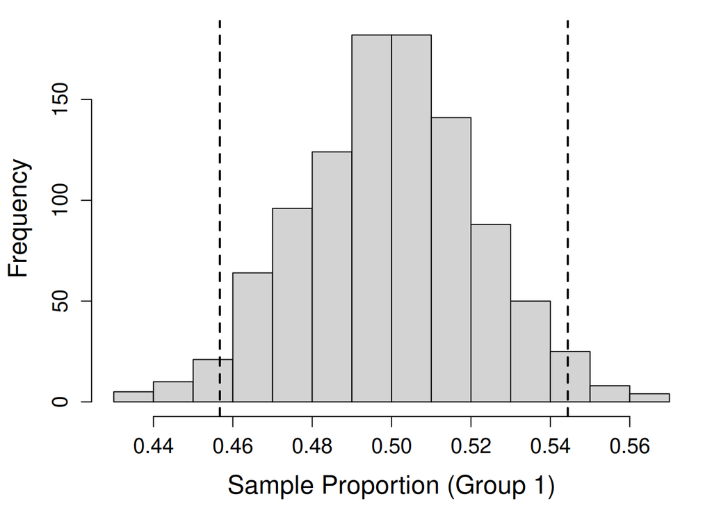

```r
# Compute 95% confidence bounds around the sampling mean
ub_x1 <- mean(mean_x1) + 1.96 * se
lb_x1 <- mean(mean_x1) - 1.96 * se

# Plot histogram of simulated sample proportions
par(mar = c(4.5, 4.5, 1, 1))
hist(mean_x1, breaks = 12,
     main = "",
     xlab = "Sample Proportion (Group 1)",
     cex.axis = 1.25, cex.lab = 1.5)
abline(v = c(lb_x1, ub_x1), lty = 2, lwd = 2)  # add CI bounds
```

```r
# pct. of observations to the right of the "upper" C.I. +
# pct. of observations to the left of the "lower" C.I.
# this should be very close to 5%
mean(ifelse(mean_x1 >= ub_x1, 1, 0)) + mean(ifelse(mean_x1 <= lb_x1, 1, 0))
```

```
[1] 0.047
```

```r
# Compute simulated differences
diff <- mean_x1 - mean_x2

# Theoretical (from our equation) SE for the difference in proportions
se <- sqrt(p1*(1-p1)/n + p2*(1-p2)/n)
se
```

```
[1] 0.03130495
```

```r
# Empirical (from our simulations) SE estimate
mean(sd_x1 + sd_x2) / sqrt(n + n)
```

```
[1] 0.03130156
```

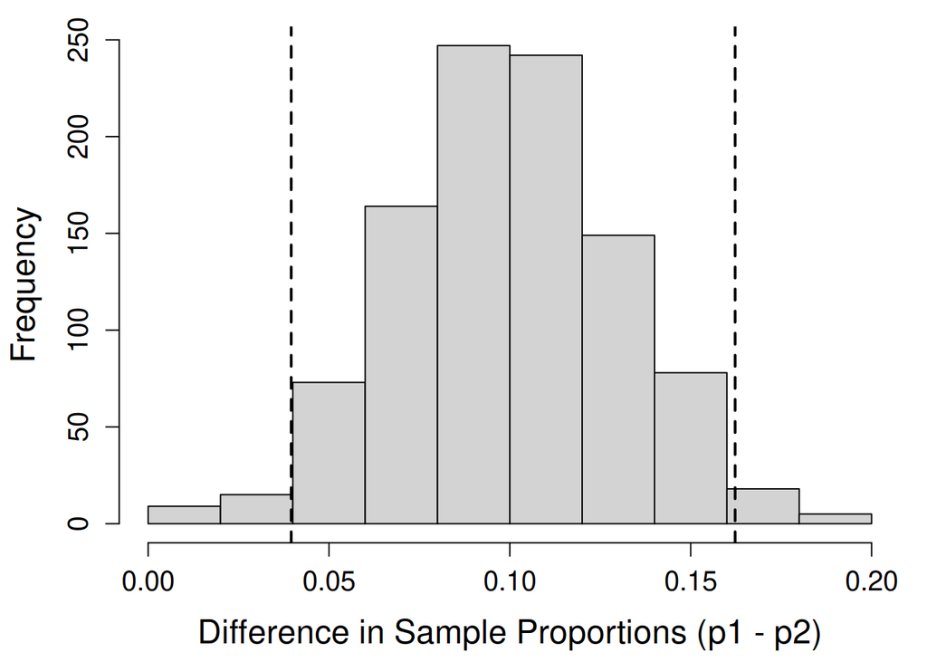

```r
# Compute 95% CIs
ub_diff_1 <- mean(diff) + 1.96 * se
lb_diff_1 <- mean(diff) - 1.96 * se

# Visualize sampling distribution of the difference
hist(diff, breaks = 12,
     main = "",
     xlab = "Difference in Sample Proportions (p1 - p2)",
     cex.axis = 1.25, cex.lab = 1.5)

# Add CI bounds
abline(v = c(lb_diff_1, ub_diff_1), lty = 2, lwd = 2)
```

```r
# pct. of observations to the right of the "upper" C.I. or...
# pct. of observations to the left of the "lower" C.I.
# this should be very close to 5%
mean(ifelse(diff >= ub_diff_1 | diff <= lb_diff_1, 1, 0))
```

```
[1] 0.042
```

### Differences of Two Proportions: Example 1

- Study of **ICU patients admitted after a heart attack**
- Randomly assigned:
  - **Treatment:** blood thinner
  - **Control:** no blood thinner
- Outcome measured: **24-hour survival**

```r
# read in data
x <- read.csv("data/cpr.csv")

# convert to matrix
z <- as.data.frame.matrix(table(x))
z$total <- rowSums(z)
z <- rbind(z, total = colSums(z))
z
```

```
          died survived total
control     39       11    50
treatment   26       14    40
total       65       25    90
```

```r
## calculate n for each group
nt <- z$total[2]
nc <- z$total[1]

## calculate p(survive) for each group
pt <- z$survived[2] / nt
pc <- z$survived[1] / nc

## 35 (22) percent of treated (control) group survive
pt; pc
```

```
[1] 0.35
```

```
[1] 0.22
```

```r
## calculate test statistics
## 0.13 p.p. difference
point_est <- pt - pc
se <- sqrt((pt * (1 - pt) / nt) + (pc * (1 - pc) / nc))

## these are the critical values for different sig. levels (two-tailed)
z <- data.frame(
  sig_level = c(0.01, 0.05, 0.1),
  z_score = c(2.576, 1.96, 1.645)
)

## confidence intervals
## note how the confidence intervals get more wide the sig. level decreases
z$min <- point_est - z$z_score * se
z$max <- point_est + z$z_score * se
z
```

```
  sig_level z_score         min       max
1      0.01   2.576 -0.11599788 0.3759979
2      0.05   1.960 -0.05717230 0.3171723
3      0.10   1.645 -0.02709104 0.2870910
```

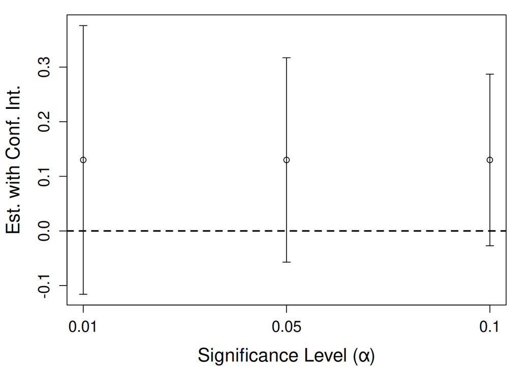

```r
# plot
par(mar = c(4.5, 4.5, 1, 1))
plot(1:3, rep(point_est, 3),
     ylim = c(min(z$min), max(z$max)),
     xlab = "Significance Level (α)",
     ylab = "Est. with Conf. Int.",
     cex.axis = 1.25,
     cex.lab = 1.5,
     xaxt = "n")
axis(1, at = 1:3, labels = c(z$sig_level), cex.axis = 1.25)
abline(h = 0, lty = 2, lwd = 2)
arrows(1:3, z$min, 1:3, z$max, length = 0.05, angle = 90, code = 3)
```

- We are **90% confident** that blood thinners change the 24-hour survival rate by between -3 and 29 percentage points for patients similar to those in the study
- Because **0% is within this range**, the evidence is inconclusive
  - We cannot determine whether blood thinners help or harm heart attack patients who have undergone CPR

### Differences of Two Proportions: Example 2

- **5-year clinical trial:** Do fish oil supplements reduce heart attack risk?
- Participants randomly assigned:
  - **Fish oil** (treatment)
  - **Placebo**
- Compare **heart attack rates** across groups

```r
# read in data
x <- read.csv("data/fish_oil.csv")

# convert to matrix
z <- as.data.frame.matrix(table(x))
z$total <- rowSums(z)
z <- rbind(z, total = colSums(z))
z
```

```
         hospital no_event total
fish oil      145    12788 12933
placebo       200    12738 12938
total         345    25526 25871
```

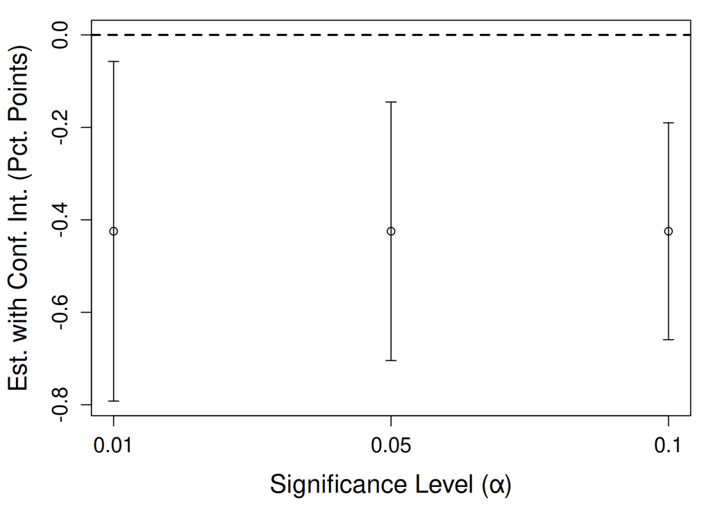

```r
## calculate n for each group
nt <- z$total[1]
nc <- z$total[2]

## calculate p(hospital) for each group
pt <- z$hospital[1] / nt
pc <- z$hospital[2] / nc

## calculate test statistics
point_est <- pt - pc
se <- sqrt((pt * (1 - pt) / nt) + (pc * (1 - pc) / nc))

z <- data.frame(
  sig_level = c(0.01, 0.05, 0.1),
  z_score = c(2.576, 1.96, 1.645)
)

z$min <- point_est - z$z_score * se
z$max <- point_est + z$z_score * se

# convert to percentage points
point_est <- point_est * 100
z[,3:4] <- z[,3:4] * 100

par(mar = c(4.5, 4.5, 1, 1))
plot(1:3, rep(point_est, 3),
     ylim = c(min(z$min), 0),
     xlab = "Significance Level (α)",
     ylab = "Est. with Conf. Int. (Pct. Points)",
     cex.axis = 1.25,
     cex.lab = 1.5,
     xaxt = "n")
axis(1, at = 1:3, labels = c(z$sig_level), cex.axis = 1.25)
abline(h = 0, lty = 2, lwd = 2)
arrows(1:3, z$min, 1:3, z$max, length = 0.05, angle = 90, code = 3)
```

- **Estimated effect:** –0.0043
  - Heart attacks were **0.43 percentage points lower** with fish oil
- **90% confidence interval:** –0.66 to –0.19 percentage points
  - Because **0 is not in the interval**, the reduction is **statistically significant**

### Practical vs. Statistical Significance

- The effect is **statistically significant**, but **very small**:
  - about **0.4 fewer heart attacks per 100 people**.
- In large samples, even **tiny effects can be statistically significant**.
- **Practical question:** Is such a small reduction worth the **costs, side effects, or effort of treatment?**

```r
# effect size relative to mean
## a 27.5% reduction!
point_est / pc
```

```
[1] -27.47197
```

### Differences of Two Proportions: Example 3

- A drone quadcopter company is considering a new manufacturer for rotor blades
  - The new manufacturer is more expensive but claims that their higher-quality blades are **3% more reliable**
- Set up the appropriate hypotheses for this test:
  - $H_0: p_{\text{highQ}} - p_{\text{standard}} = 0.03$
  - $H_A: p_{\text{highQ}} - p_{\text{standard}} \neq 0.03$
- Using these data, evaluate the hypotheses above at a significance level of 5%.

### Compute the Point Estimate and Standard Error

```r
# read in the data
x <- read.csv("data/quad.csv")

# share of ours and theirs which pass inspection
p_us <- sum(ifelse(x$prospective_supplier == "pass", 1, 0)) / 1000
p_them <- sum(ifelse(x$current_supplier == "pass", 1, 0)) / 1000

# 95.8% of ours are good vs. 89.9% of theirs
p_us; p_them
```

```
[1] 0.958
```

```
[1] 0.899
```

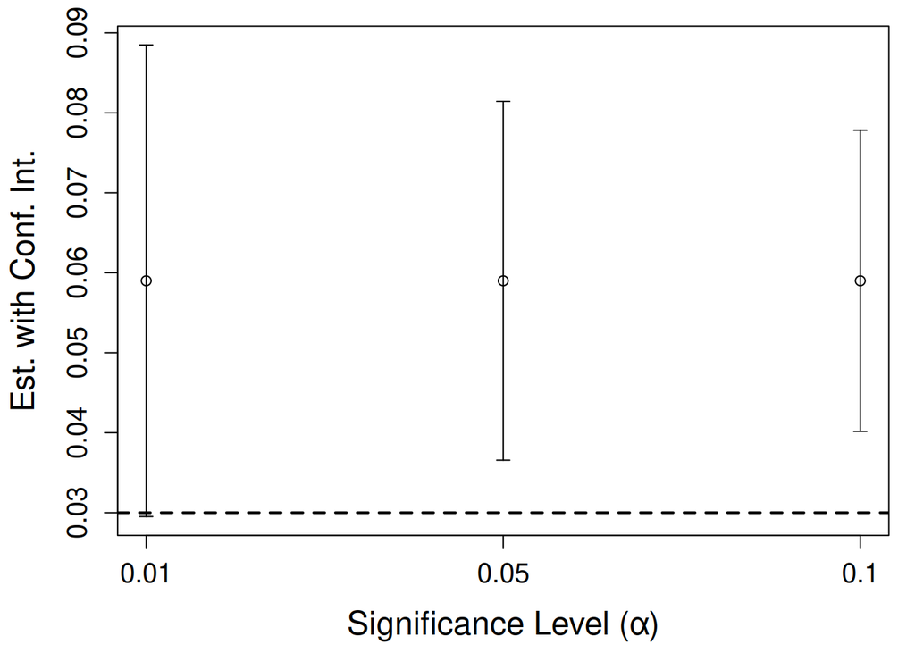

```r
# 5.9 p.p difference
point_est <- p_us - p_them
se <- sqrt( p_us * (1 - p_us) / 1000 +  p_them * (1 - p_them) / 1000 )

z <- data.frame(
  sig_level = c(0.01, 0.05, 0.10),
  z_score = c(2.576, 1.96, 1.645)
)
z$min <- (point_est - z$z_score * se)
z$max <- (point_est + z$z_score * se)

# plot estimates with conf. intervals
## We say that there are stat. sign. differences at the 90 and 95% levels, but not 99%
par(mar = c(4.5, 4.5, 1, 1))
plot(1:3, rep(point_est, 3),
     ylim = c(min(z$min), max(z$max)),
     xlab = "Significance Level (α)",
     ylab = "Est. with Conf. Int.",
     cex.axis = 1.25,
     cex.lab = 1.5,
     xaxt = "n")
axis(1, at = 1:3, labels = c(z$sig_level), cex.axis = 1.25)
abline(h = 0.03, lty = 2, lwd = 2)
arrows(1:3, z$min, 1:3, z$max, length = 0.05, angle = 90, code = 3)
```

```r
## Note that we can evaluate this another way as well!
## Remember good ole standardization? Where would our point estimate fall in there?
## Recall the null hypothesis? Our blades need to be 3% more reliable
## Thus subtract 3% from our point estimate (5.9%). Standardize by dividing by the SE
## z-score
z <- (point_est - 0.03) / se

# 2.53 standard deviations away from the mean! > 1.96
z
```

```
[1] 2.533403
```

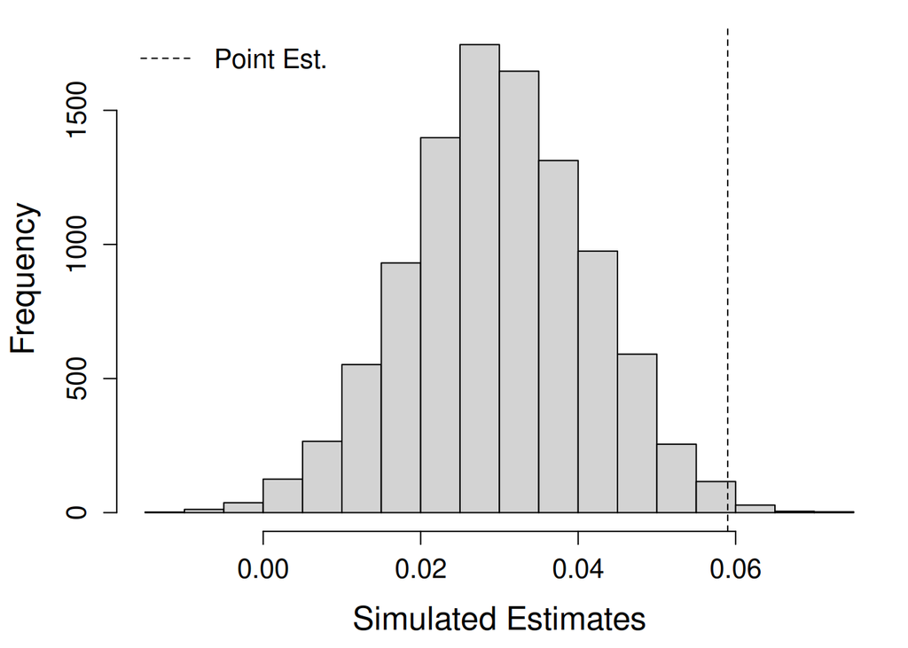

```r
# simulate null hypothesis (note the mean = 0.03, sd = se)
set.seed(1)
sim <- rnorm(10000, mean = 0.03, sd = se)

# visualize the result
par(mar = c(4.5, 4.5, 1, 1))
hist(sim, main = "", xlab = "Simulated Estimates",
     cex.lab = 1.5, cex.axis = 1.25)
abline(v = point_est, lty = 2)
legend("topleft",
       legend = c("Point Est."),
       lty = 2, cex = 1.25, bty = "n")
```

```r
# Prob. of observing a value this extreme or larger (from simulation) if null is true
1 - mean(ifelse(point_est >= sim, 1, 0))
```

```
[1] 0.0049
```

```r
# Prob. of observing a value this extreme or larger (from computer) if null is true
1 - pnorm(z)
```

```
[1] 0.005648044
```

- From the standard normal distribution:
  - The right-tail area is approximately 0.005
  - Doubling for a two-tailed test gives p = 0.01
  - Since p = 0.01 < 0.05, we **reject the null hypothesis**
- We find statistically significant evidence that the higher-quality blades have a pass rate greater than 3% higher than the standard blades — exceeding the company’s claims.

## t-distributions

- When the population standard deviation ($\sigma$) is unknown (which is most of the time), we rely on the $t$-distribution instead of the normal model.
  - The $t$-test helps us quantify uncertainty and make inferences about population parameters using sample data
- We use a **t-distribution with (df = n - 1)** to model the sample mean when the sample size is small.
  - As the number of observations increases, the **degrees of freedom (df)** also increase.
  - With larger df, the **t-distribution more closely resembles the standard normal distribution**.
- The primary intuition of t-stats is that we require a **greater burden of proof** when we have few observations
  - Larger critical values used constructing confidence intervals are **more conservative**

### Degrees of Freedom

- **Degrees of freedom (df):** number of **independent pieces of information** used to estimate a statistic.
  - $df \neq n$
  - Imagine tossing a coin 100 times – if you get 55 heads, then you know you got 45 tails (1 df)
  - Imagine a traffic light – if not yellow or red, then green (2 df)
- Calculate the standard deviation of three exam grades
  - $s = \sqrt{\frac{ \Sigma (x_i - \bar{x}) }{n - 1} }$
  - If the mean is already known, then you don’t **need** all of the other values in the sample
  - If $\bar{x} = 85$ and $x_1 = 80$ and $x_2 = 85$, then $x_3 = 90$ is no longer independent
- **Why it matters**
  - Determines the shape of distributions like **$t$, $F$, and $\chi^2$**.
  - **More df - more information - distributions become narrower and more normal.**

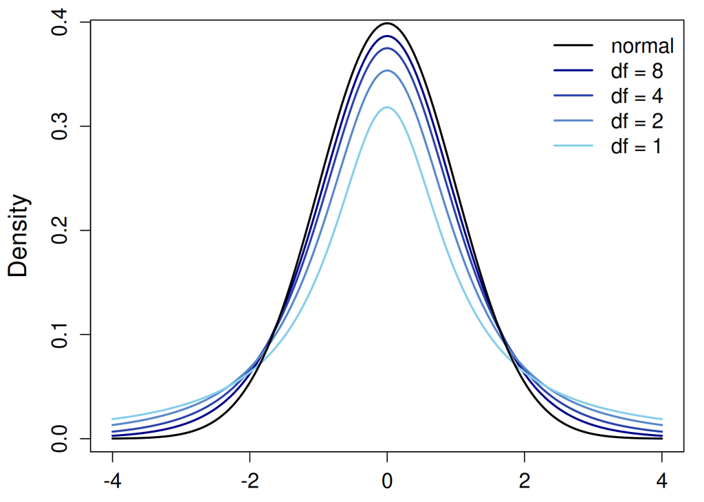

```r
# generate 200 observations between -4 and 4
x <- seq(-4, 4, length = 200)

## plot parameters
dfs <- c(8, 4, 2, 1)
cols <- colorRampPalette(c("darkblue", "skyblue"))(4)
par(mar = c(2.5, 4.5, 1, 1))

## plot loop
for (j in seq_along(dfs)) {

  df <- dfs[j]
  y <- dt(x, df = df)

  if (j == 1) {
    plot(x, y, type = "l", ylab = "Density", xlab = "",
         cex.axis = 1.25, cex.lab = 1.5, lwd = 2, col = cols[j])
  }else {
    lines(x, y, lwd = 2, col = cols[j])
  }
}

## lines and legend on plot
lines(x, dnorm(x), lwd = 2)
legend("topright", legend = c("normal", paste0("df = ", dfs)),
       col = c("black", cols), lwd = 2, bty = "n", cex = 1.25)
```

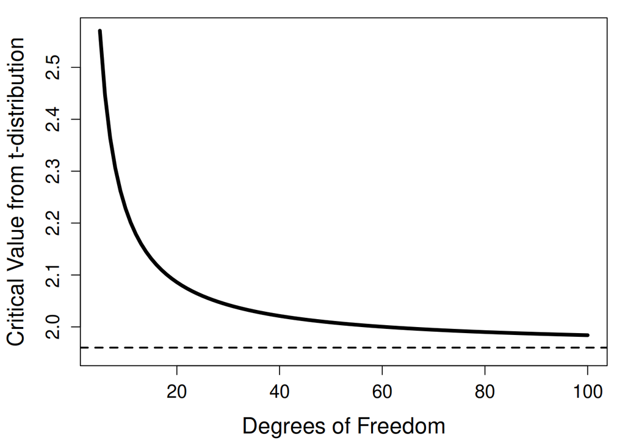

```r
# for degrees of freedom 5:100, calculate the critical value
## cv means that 2.5% of values fall to the right of this number
## cv = 1.96 with a normal distribution!

x <- data.frame(
  df = 5:100,
  qt = qt(.975, df = 5:100)
)

# plot
par(mar = c(4.5, 4.5, 1, 1))
plot(x$df, x$qt,
     type = "l",
     lwd = 4,
     xlab = "Degrees of Freedom",
     ylab = "Critical Value from t-distribution",
     cex.lab = 1.5,
     cex.axis = 1.25,
     ylim = c(1.95, max(x$qt)))
abline(h = 1.96, lty = 2, lwd = 2)
```

### t-statistic equation

$$t = \dfrac{x_i - \bar{x}}{ \sigma_x / \sqrt{n}}$$

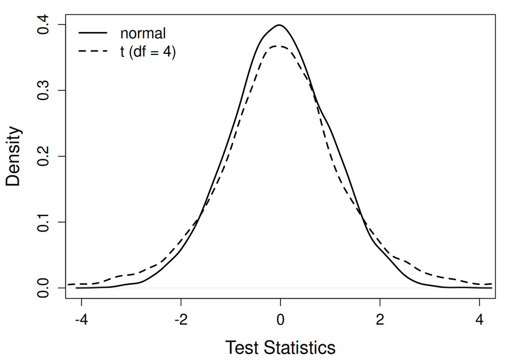

```r
# few number of observations; many simulations
n <- 5
Nsim <- 10000

# reject the null if n is large
rejections_normal <- 0

# reject the null if n is small
rejections_t <- 0

# store t-stats (this is an empty list)
t <- list()

# loop
for(i in 1:Nsim){

  # simulate data (n = 5)
  set.seed(i)
  x <- rnorm(n)

  # calc. t-stat
  tstat <- (mean(x) - 0) / (sd(x)/sqrt(n))

  # normal critical value
  if(abs(tstat) > 1.96){
    rejections_normal <- rejections_normal + 1
  }

  # correct t critical value
  if(abs(tstat) > qt(0.975, df = n-1)){
    rejections_t <- rejections_t + 1
  }

  # store t-stat in our list
  t[i] <- tstat

}

# gather data from loop; convert to distribtuion
t <- density(unlist(t))

# generate a normal dist.
set.seed(1)
z <- rnorm(10000)

# plot
## Note that the tails of the distribution are larger for the t-stat!
par(mar = c(4.5, 4.5, 1, 1))
plot(density(z),
     xlim = c(-4, 4),
     lwd = 2,
     xlab = "Test Statistics",
     ylab = "Density",
     main = "",
     cex.lab = 1.5,
     cex.axis = 1.25)
lines(t, lty = 2, lwd = 2)
legend("topleft",
       legend = c("normal", "t (df = 4)"),
       lwd = 2,
       lty = c(1, 2),
       bty = "n",
       cex = 1.25)
```

```r
# p-value if we use cv = 1.96 (wrong)
## this is not conservative enough!
rejections_normal / Nsim
```

```
[1] 0.1245
```

```r
# p-value if we use cv = t* (correct)
## this should be close to 5%
rejections_t / Nsim
```

```
[1] 0.0515
```

### t-distibutions: Example 1

- Let’s apply the t-distribution in a real-world example involving mercury content in dolphin muscle
  - $H_0: Hg = 2$
  - $H_A: Hg > 2$
  - Note: is don’t make sense to do a two-tailed (heh, get it? dolphins…) test here since mercury content cannot be negative.
- It isn’t ethical to test 1000s of dolphins if you don’t need to!
  - We can adjust statistically for the fact that we have very few observations (which is good!)

```r
# read in data
y <- read.csv("data/dolphins.csv")

# see data
head(y)
```

```
  dolphin mercury
1       1     1.7
2       2     1.7
3       3     2.1
4       4     2.3
5       5     2.8
6       6     2.8
```

```r
# number of observations
n <- nrow(y)
n
```

```
[1] 19
```

```r
# prep simulation
Nsim <- 100000
t <- list()

# point est
se_obs <- sd(y$mercury) / sqrt(n)
t_stat_obs <- (mean(y$mercury) - 2) / se_obs

# 5.13 standard deviations greater than the mean is large!
# however there are very few observations
t_stat_obs
```

```
[1] 5.13836
```

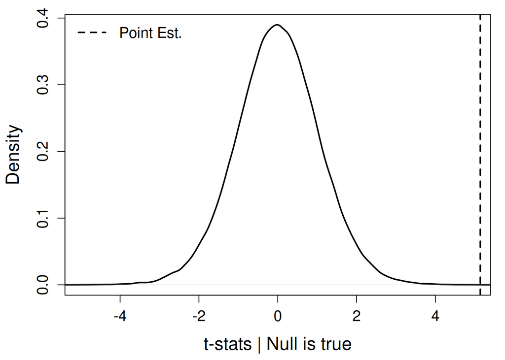

```r
# to evluate this, lets simulate null hypothesis
for(i in 1:Nsim){

  # generate data, null = 2
  set.seed(i)
  x <- rnorm(n, mean = 2, sd = sd(y$mercury))

  # summary stats
  point_est <- mean(x)
  se <- sd(x) / sqrt(n)

  # t-stat
  t[i] <- (point_est - 2) / se

}
t <- unlist(t)

# plot our simulated t-stats
par(mar = c(4.5, 4.5, 1, 1))
plot(density(t),
     lwd = 2,
     cex.lab = 1.5,
     cex.axis = 1.25,
     xlab = "t-stats | Null is true",
     main = "",
     xlim = c(-5, 5))
abline(v = t_stat_obs, lty = 2, lwd = 2)
legend("topleft",
       legend = c("Point Est."),
       lty = 2,
       lwd = 2,
       bty = "n",
       cex = 1.25)
```

```r
# simulated p-value
# chance that we would observe an event this great if Hg = 2 = 4 / 100k
table(ifelse(t_stat_obs < t, 1, 0))
```

```
    0     1
99996     4
```

```r
# alternatively, you can use 't.test' in R
t.test(y$mercury,
       alternative = "greater",
       mu = 2)
```

```
    One Sample t-test

data:  y$mercury
t = 5.1384, df = 18, p-value = 3.444e-05
alternative hypothesis: true mean is greater than 2
95 percent confidence interval:
 3.71908     Inf
sample estimates:
mean of x
 4.594737
```

### t-distibutions: Example 2

- Does treatment using embryonic stem cells (ESCs) help improve heart function after a heart attack?
  - Each sheep was **randomly** assigned to either an **ESC treatment group** or a **control group**.
  - Researchers measured the **change in heart pumping capacity** after treatment.
  - Positive values indicates stronger recovery.
- Hypothesis testing: Is there evidence that that there were differences in recovery time between groups?
  - $H_O: H_{esc} = H_{ctrl}$
  - $H_O: H_{esc} \neq H_{ctrl}$

```r
# read in data
y <- read.csv("data/stem_cell.csv")

# calculate differences
y$diff <- y$after - y$before
y
```

```
   trmt before after  diff
1  ctrl  35.25 29.50 -5.75
2  ctrl  36.50 29.50 -7.00
3  ctrl  39.75 36.25 -3.50
4  ctrl  39.75 38.00 -1.75
5  ctrl  41.75 37.50 -4.25
6  ctrl  45.00 42.75 -2.25
7  ctrl  47.00 39.00 -8.00
8  ctrl  52.00 45.25 -6.75
9  ctrl  52.00 52.25  0.25
10  esc  29.00 31.00  2.00
11  esc  29.50 43.75 14.25
12  esc  34.00 36.00  2.00
13  esc  35.00 41.50  6.50
14  esc  35.25 39.50  4.25
15  esc  42.50 40.00 -2.50
16  esc  44.00 45.75  1.75
17  esc  49.25 55.25  6.00
18  esc  53.75 51.00 -2.75
```

```r
# subset each group
t <- subset(y, y$trmt == "esc")
c <- subset(y, y$trmt == "ctrl")

# point estimate (mean treated - mean control)
point_est <- mean(t$diff) - mean(c$diff)
point_est
```

```
[1] 7.833333
```

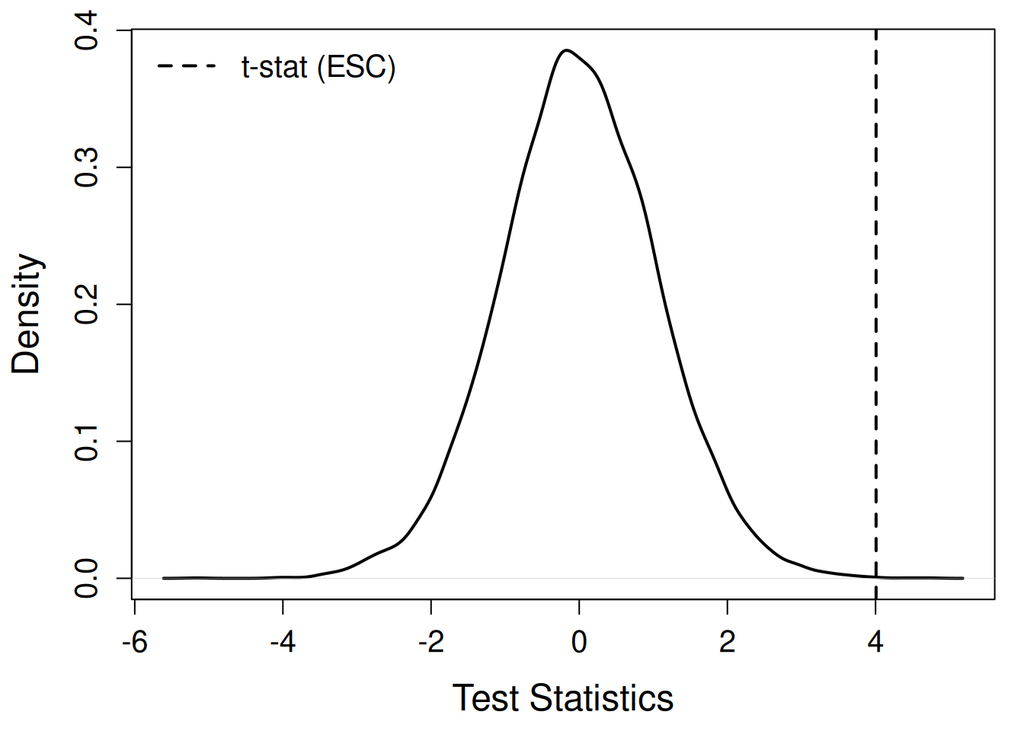

```r
# standard error (difference in groups equation)
se_t <- sd(t$diff)^2 / 9
se_c <- sd(c$diff)^2 / 9
se <- sqrt(se_t + se_c)

# t-statistic
t_stat_esc <- point_est / se

## is a t-stat of 4 large enough to offset having very few observations? Let's simulate!
# few number of observations; many simulations
n <- 9
Nsim <- 10000

# store t-stats (this is an empty list)
t <- list()

# loop
for(i in 1:Nsim){

  # simulate data (n = 9) for group 1
  set.seed(i)
  x <- rnorm(n)

  # simulate data (n = 9) for group 1
  set.seed(Nsim + i)
  z <- rnorm(n)

  # difference in means between the groups
  point_est <- mean(x) - mean(z)

  # standard error
  se1 <- sd(x)^2 / n
  se2 <- sd(z)^2 / n
  se <- sqrt(se1 + se2)

  # calc. t-stat
  tstat <- point_est / se

  # store t-stat in our list
  t[i] <- tstat

}

# gather data from loop
t <- unlist(t)

# plot
## Note that the tails of the distribution are larger for the t-stat!
par(mar = c(4.5, 4.5, 1, 1))
plot(density(t),
     lwd = 2,
     xlab = "Test Statistics",
     ylab = "Density",
     main = "",
     cex.lab = 1.5,
     cex.axis = 1.25)
abline(v = t_stat_esc, lty = 2, lwd = 2)
legend("topleft",
       legend = c("t-stat (ESC)"),
       lwd = 2,
       lty = 2,
       bty = "n",
       cex = 1.25)
```

```r
# if there is no difference between groups...
# what proportion of times we would find an effect as extreme as seen IRL?
# 4/10k is our p-value!
table(ifelse(abs(t) >= t_stat_esc, 1, 0))
```

```
   0    1
9996    4
```

```r
# alternatively, you can use this
t.test(y$diff[y$trmt == "esc"], y$diff[y$trmt == "ctrl"])
```

```
    Welch Two Sample t-test

data:  y$diff[y$trmt == "esc"] and y$diff[y$trmt == "ctrl"]
t = 4.0073, df = 12.225, p-value = 0.001678
alternative hypothesis: true difference in means is not equal to 0
95 percent confidence interval:
  3.582916 12.083750
sample estimates:
mean of x mean of y
 3.500000 -4.333333
```

## Chi-Squared Distributions

- $\chi$ = the Greek letter for “chi” (pronounced like “kai”)
- The $\chi^2$ distribution is a continuous probability distribution
  - If a variable $Z$ has the standard normal distribution, then $Z^2$ has the $\chi^2$ distribution with one **degree of freedom**
- If $Z_1, Z_2,..., Z_k$ are independent standard normal variables, then…
  - $Z_1^2 + Z_2^2 +...+ Z_k^2$
  - …has a $\chi^2$ distribution with $k$ **degrees of freedom**

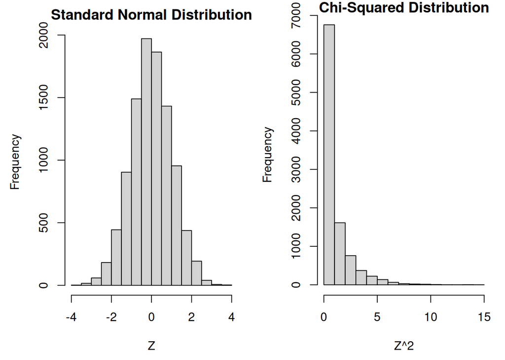

```r
# generate 10k random, standardized numbers
set.seed(1)
x <- rnorm(10000, mean = 0, sd = 1)

## square it
x2 <- x^2

# Two plots side by side
par(mfrow = c(1, 2), mar = c(4.5, 4.5, 2, 1))

# plot 1
hist(x,
     main = "Standard Normal Distribution",
     xlab = "Z")

# plot 2
par(mar = c(4.5, 4.5, 1, 1))
hist(x2,
     main = "Chi-Squared Distribution",
     xlab = "Z^2")
```

```r
# Reset layout after plotting
par(mfrow = c(1, 1))
```

### Chi-Squared Distributions: Properties

- mean: $\mu = k$
- variance: $\sigma^2 = 2k$
- mode occurs at $\mu - 2$

```r
# expected = 1
mean(x2)
```

```
[1] 1.024806
```

```r
# expected = 2
var(x2)
```

```
[1] 2.063464
```

```r
# estimate chi-squared (df = 4)
k <- 4
for(i in 1:k){

  # generate data
  set.seed(i)
  x <- rnorm(10000, mean = 0, sd = 1)

  # square it
  x2 <- x^2

  # add it to what came before
  if(i == 1){

    z2 <- x2

  }else{

    z2 <- z2 + x2

  }
}

# expected: k = 4
mean(z2)
```

```
[1] 4.023251
```

```r
# expected: 2k = 2*4 = 8
var(z2)
```

```
[1] 7.926623
```

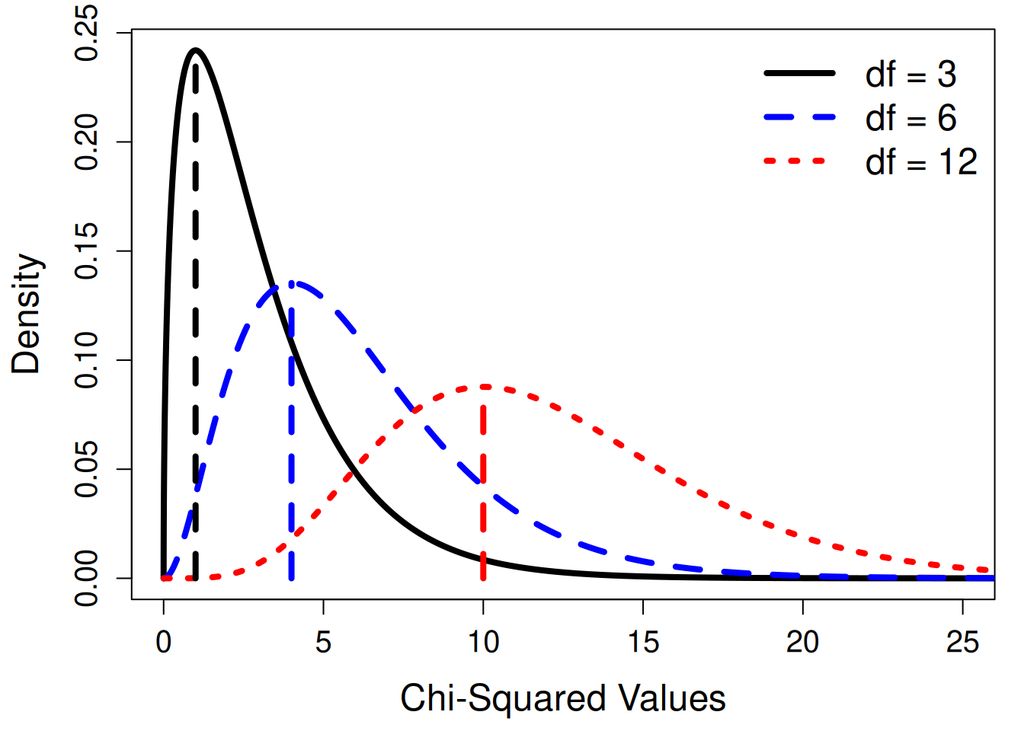

```r
# simulate data again. This is all just for visualizing the distributions as k grows.
# No need to follow along here with the code.
## increase variance for better data visualization
set.seed(1)
z <- rnorm(10000, mean = 0, sd = 2)
z2 <- z*z

# generate density plots
y <- data.frame(
  x2 = z2,
  df3 = dchisq(z2, df = 3),
  df6 = dchisq(z2, df = 6),
  df12 = dchisq(z2, df = 12)
)
y <- y[order(y$x2),]

# plot
par(mar = c(4.5, 4.5, 1, 1))
plot(y$x2, y$df3, type = "l",
     main = "",
     xlab = "Chi-Squared Values",
     ylab = "Density",
     cex.axis = 1.25,
     cex.lab = 1.5,
     lwd = 4,
     xlim = c(0, 25))
lines(y$x2, y$df6, lty = 2, col = "blue", lwd = 4)
lines(y$x2, y$df12, lty = 3, col = "red", lwd = 4)
legend("topright",
       legend = c("df = 3",
                  "df = 6",
                  "df = 12"),
       col = c("black", "blue", "red"),
       lty = 1:3, lwd = 4,
       bty = "n", cex = 1.5)
segments(3 - 2, 0, 3 - 2, max(y$df3), lty = 2, lwd = 4)
segments(6 - 2, 0, 6 - 2, max(y$df6), lty = 2, lwd = 4, col = "blue")
segments(12 - 2, 0, 12 - 2, max(y$df12), lty = 2, lwd = 4, col = "red")
```

### Chi-Squared Tests

- This technique is commonly used in two settings:
  - To determine whether a **sample is representative** of a larger population across several groups
  - To evaluate whether observed data **follow a specified theoretical distribution** (e.g., normal, geometric, Poisson)
- Allows us to examine **all bins simultaneously**, rather than testing one or two categories in isolation

$$\chi^2 = \sum_i \frac{(O_i - E_i)^2}{E_i}$$

- Where:
  - $O_i$ = observed count in category $i$
  - $E_i$ = expected count (null hypothesis)
- This statistic follows a **chi-squared distribution** with $(k - 1)$ degrees of freedom, where $k$ is the number of categories

### Chi-Squared Tests: Example 1

- Consider data from a **random sample of 275 jurors** in a small county
  - We would like to test whether this sample is **racially representative** of the eligible population of jurors (i.e., registered voters)
  - $H_0$: Jurors are randomly selected; differences reflect natural sampling variation
  - $H_A$: Jurors are not randomly selected; differences are too large to attribute to chance alone

```r
# data
x <- read.csv("data/jurors.csv")
y <- read.csv("data/county_voters.csv")

# number of jurors
n <- nrow(x)
n
```

```
[1] 275
```

```r
# expected racial composition (as %)
e <- table(y$race) / nrow(y)
e
```

```
   black hispanic    other    white
    0.07     0.12     0.09     0.72
```

```r
# expected number of jurors by race/ethnicity
e <- e * n

# what did we observe IRL?
o <- table(x$race)
o
```

```
   black hispanic    other    white
      26       25       19      205
```

```r
# how many groups?
k <- 4

# test statistic
X2_obs <- sum( (o - e)^2  / e )
X2_obs
```

```
[1] 5.88961
```

```r
# # simulate the null; random multinominal matrix
B <- 10000
set.seed(1)
Y <- t(rmultinom(B, size = n, prob = e))
m <- matrix(e, B, k, byrow=TRUE)
colnames(m) <- colnames(Y) <- names(e)

# simulated
head(Y)
```

```
     black hispanic other white
[1,]    17       26    32   200
[2,]    16       41    26   192
[3,]    21       32    20   202
[4,]    21       31    19   204
[5,]    17       26    24   208
[6,]    24       35    25   191
```

```r
# expected
head(m)
```

```
     black hispanic other white
[1,] 19.25       33 24.75   198
[2,] 19.25       33 24.75   198
[3,] 19.25       33 24.75   198
[4,] 19.25       33 24.75   198
[5,] 19.25       33 24.75   198
[6,] 19.25       33 24.75   198
```

```r
# simulated test statistic
X2_sim <- rowSums( (Y - m)^2 / m )

# what % of the time would observe something as unrepresentative as IRL?
p_value1 <- mean(X2_sim >= X2_obs)
p_value1
```

```
[1] 0.1192
```

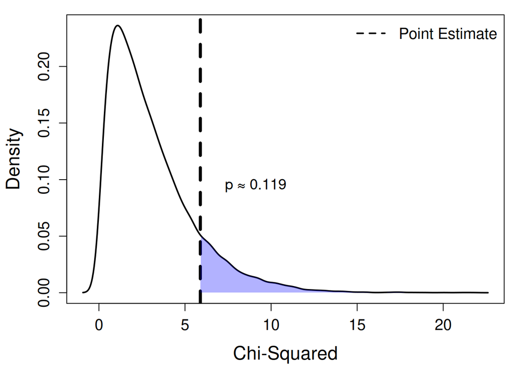

```r
# plot test statistic on chi-squared dist.
# this gets complicated. You can just see the figure.
par(mar = c(4.5, 4.5, 1, 1))
d_X2_sim <- density(X2_sim)
par(mar = c(4.5, 4.5, 1, 1))
plot(d_X2_sim$x, d_X2_sim$y, type = "l",
     xlab = "Chi-Squared", ylab = "Density",
     cex.lab = 1.5, cex.axis = 1.25, lwd = 2)
abline(v = X2_obs, lty = 2, lwd = 4)

# add color
x_tail <- d_X2_sim$x[d_X2_sim$x >= X2_obs]
y_tail <- d_X2_sim$y[d_X2_sim$x >= X2_obs]
polygon(c(X2_obs, x_tail, max(x_tail)),
        c(0, y_tail, 0),
        col = rgb(0,0,1,0.3), border = NA)

# add text
text(X2_obs + 1, max(d_X2_sim$y) * 0.4,
     paste0("p ≈ ", round(p_value1, 3)),
     pos = 4, cex = 1.2)
legend("topright",
       legend = c("Point Estimate"),
       lty = 2, lwd = 2, bty = "n",
       cex = 1.25)
```

### Chi-Squared Tests: Example 2

- Suppose we analyze **daily stock returns from the S&P 500** over a 10-year period to test whether market movements are **independent across days**
  - “Does knowing whether the market went up or down yesterday help predict what happens today?”
- If daily market movements are truly **independent**, the waiting time between positive days should follow a **geometric distribution**
- The geometric distribution gives the probability of waiting $k$ trials to observe the first success
  - $p$ = probability that a given day is an Up day
  - $X$ = number of days until the next Up day

$$P(X = k) = (1 - p)^{k - 1}p$$

```r
# read in "data"
x <- data.frame(
  days = 1:7,
  observed = c(717, 369, 155, 69, 28, 14, 10)
)

# "up" 54.5% of days
p <- 0.545
x$expected <- round((1-p)^((x$days)-1)*p*sum(x$observed)) # geo. distribution
x
```

```
  days observed expected
1    1      717      742
2    2      369      338
3    3      155      154
4    4       69       70
5    5       28       32
6    6       14       14
7    7       10        7
```

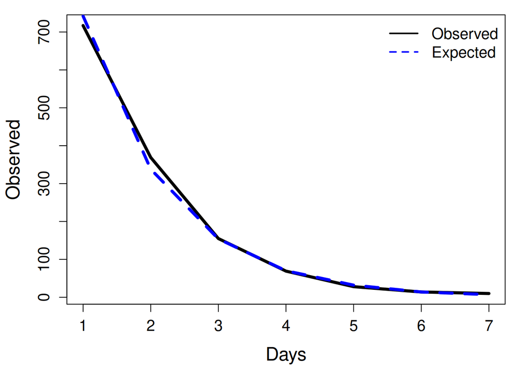

```r
# plot
par(mar = c(4.5, 4.5, 1, 1))
plot(x$days, x$observed, type = "l", lwd = 4,
     ylab = "Observed", xlab = "Days",
     cex.axis = 1.25, cex.lab = 1.5)
lines(x$days, x$expected, lty = 2, lwd = 4, col = "blue")
legend("topright",
       legend = c("Observed", "Expected"),
       lwd = 2, lty = c(1, 2),
       col = c("black", "blue"),
       bty = "n", cex = 1.25)
```

```r
# test statistic
x2 <- sum( (x$observed - x$expected)^2 / x$expected )
x2
```

```
[1] 5.492007
```

```r
# simulate null
for(i in 1:6){
  set.seed(i)
  z <- rnorm(sum(x$observed), mean = 0, sd = 1)
  if(i == 1){
    y <- z^2
  }else{
    y <- y + z^2
  }
}

# simulated p-value
mean(ifelse(x2 > y, 1, 0))
```

```
[1] 0.5198238
```

```r
# formula p-value
pchisq(x2, df = 6)
```

```
[1] 0.5175767
```

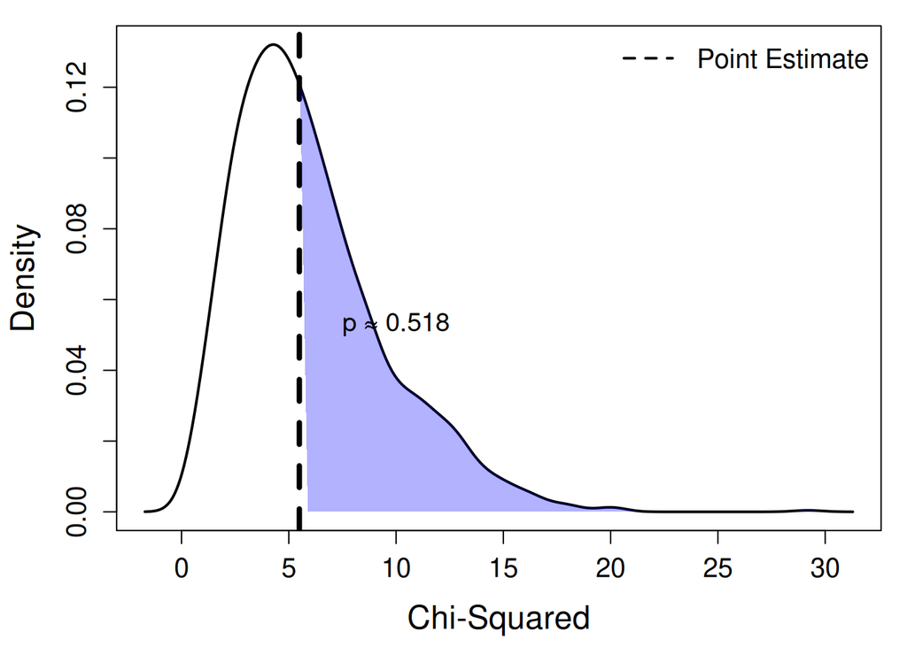

```r
# plot null
d_X2_sim <- density(y)
pvalue2 <- pchisq(x2, df = 6)
par(mar = c(4.5, 4.5, 1, 1))
plot(d_X2_sim$x, d_X2_sim$y, type = "l",
     xlab = "Chi-Squared", ylab = "Density",
     cex.lab = 1.5, cex.axis = 1.25, lwd = 2)
abline(v = x2, lty = 2, lwd = 4)

x_tail <- d_X2_sim$x[d_X2_sim$x >= x2]
y_tail <- d_X2_sim$y[d_X2_sim$x >= x2]

polygon(c(X2_obs, x_tail, max(x_tail)),
        c(0, y_tail, 0),
        col = rgb(0,0,1,0.3), border = NA)

text(X2_obs + 1, max(d_X2_sim$y) * 0.4,
     paste0("p ≈ ", round(pvalue2, 3)),
     pos = 4, cex = 1.2)
legend("topright",
       legend = c("Point Estimate"),
       lty = 2, lwd = 2, bty = "n",
       cex = 1.25)
```

## ANOVA and F-statistics

- When comparing **more than two groups**, we might be tempted to run multiple pairwise tests:
  - Group 1 vs. 2, Group 1 vs. 3, Group 2 vs. 3, etc.
- **Problem:** Multiple tests increase the chance of **false positives**
- **Solution**: Use a **single, holistic test** to compare all group means at once

$$H_0: \mu_1 = \mu_2 = \cdots = \mu_k
\quad\quad
H_A: \text{At least one mean differs}$$

- ANOVA: tests whether there is evidence that **at least one mean differs**
  - **Between-group variation** (differences in group means)
  - **Within-group variation** (random noise)
  - **Intuition:** If group differences are large *relative to* within-group variation, we reject the null.
- This produces the **F-statistic**

### ANOVA: Example 1

- Suppose a statistics department runs **three sections** (A, B, and C) of an introductory statistics course
  - We want to know whether there are **statistically significant differences** in the **average final exam scores**

#### ANOVA: SSG

- The **sum of squares for the groups** (SSG) measures the differences between the group means $\bar{x}_i$ and the grand mean $\bar{x}$ like so:

$$SSG = \sum_{i=1}^k n_i (\bar{x}_i - \bar{x})^2$$

```r
# grades in each section
a <- c(90, 87, 88, 78)
b <- c(87, 85, 80)
c <- c(95, 93, 90, 88, 85)

# number of grades in each section
na <- length(a)
nb <- length(b)
nc <- length(c)

# average grades in each section
ua <- mean(a)
ub <- mean(b)
uc <- mean(c)

# grand mean
u <- mean(c(a, b, c))

# SSG
SSG <- na*(ua - u)^2 + nb*(ub - u)^2 + nc*(uc - u)^2
SSG
```

```
[1] 84.11667
```

#### ANOVA: MSG

- The **mean square between groups** (MSG) is calculated using both the groups’ degrees of freedom $df_G$ and the sum of squares between groups SSG:

$$MSG = \dfrac{1}{k - 1} SSG$$

```r
k <- 3
df1 <- k - 1

MSG <- SSG / df1
MSG
```

```
[1] 42.05833
```

#### ANOVA: SSE

- The **sum of squared errors** (SSE) is the sum of the squares of the differences between each sample’s observations with each respective sample mean
  - The calculation is simplified by first finding the variance $s_i^2$ of each sample:

$$SSE = \sum_{i = 1}^k (n_i - 1) s_i^2$$

```r
# standard errors for each group
sa <- sd(a)
sb <- sd(b)
sc <- sd(c)
sa; sb; sc
```

```
[1] 5.315073
```

```
[1] 3.605551
```

```
[1] 3.962323
```

```r
# SSE
SSE <- (na - 1)*sa^2 + (nb - 1)*sb^2 + (nc - 1)*sc^2
SSE
```

```
[1] 173.55
```

#### ANOVA: MSE

$$MSE = \dfrac{1}{n - k} SSE$$

```r
# MSE
n <- length(c(a, b, c))
MSE <- SSE / (n - k)
MSE
```

```
[1] 19.28333
```

#### ANOVA: F-stat

- We now have comparable measures of variability both **between** the groups (MSG) and **within** the groups (MSE).
  - If variation among group means is simply random, F is typically close to 1

$$F = \dfrac{MSG}{MSE}$$

```r
# f-stat
f_stat <- MSG / MSE
f_stat
```

```
[1] 2.181072
```

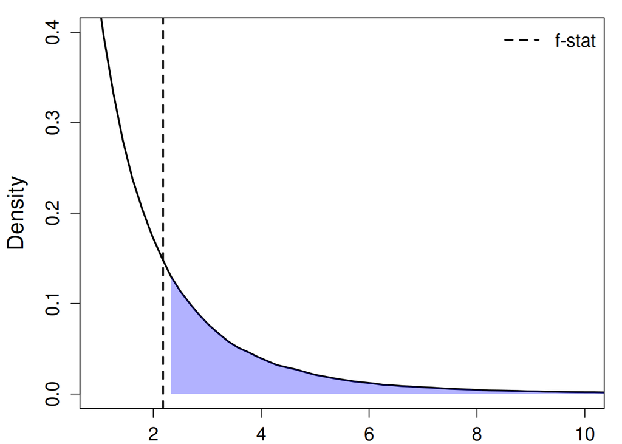

```r
# generate f-dist
set.seed(1)
x <- rf(1e6, df1 = k - 1, df2 = n - k)
dx <- density(x)

# plot
par(mar = c(2, 4.5, 1, 1))
plot(dx$x, dx$y, type = "l", lwd = 2,
     ylab = "Density", cex.lab = 1.5, cex.axis = 1.25,
     xlim = c(1, 10), ylim = c(0, 0.4))
abline(v = f_stat, lty = 2, lwd = 2)
x_fill <- dx$x[dx$x >= f_stat]
y_fill <- dx$y[dx$x >= f_stat]
polygon(c(min(x_fill), x_fill, f_stat),
        c(0, y_fill, 0),
        col = rgb(0, 0, 1, 0.3), border = NA)
legend("topright",
       legend = c("f-stat"),
       lwd = 2, lty = 2,
       cex = 1.25, bty = 'n')
```

```r
# simulated p-value; FTR
1 - mean(ifelse(f_stat > x, 1, 0))
```

```
[1] 0.169123
```

```r
# estimated p-value; FTR
z <- data.frame(
  score = c(a, b, c),
  group = c(rep('a', na), rep('b', nb), rep('c', nc))
)
summary(aov(score ~ group, z))
```

```
            Df Sum Sq Mean Sq F value Pr(>F)
group        2  84.12   42.06   2.181  0.169
Residuals    9 173.55   19.28
```

## Cheat Sheet: When to Use Which Test?

- Comparing means?
  - Is the population $\sigma$ known? $\rightarrow$ z-test; otherwise t-test
    - (Rule of thumb: with $n \geq 30$ the two are nearly identical anyway)
  - What’s the statistic? $\ t = \dfrac{\bar{x} - \mu}{s/\sqrt{n}}$ (one sample)
  - Two independent groups? $\ t = \dfrac{\bar{x}_1 - \bar{x}_2}{\sqrt{s_1^2/n_1 + s_2^2/n_2}}$
- 3+ groups?
  - Comparing means? $\rightarrow$ ANOVA
  - Categorical / frequency data? $\rightarrow \chi^2$